# Assignment 3

2021-11-22

## Introduction

The aim of this assignment was to use Chi-square (χ2) tests to analyze count data. In part 1 I used a dataset provided by the course. In Part 2 I analyzed a different dataset of my own choosing, specifically a dataset about religiosity and beliefs that abortion should be banned.

## Methods

For both parts of the assignment, the workflow was as follows:

1. Import data into R.
2. Restructure the data according to needs for answering the questions.
3. Visualize the count data in a meaningful way.
4. Perform the Chi-square test and report the results.s

## Results

### Part 1: Are there any significant associations between the personality of students and preferred animal?

Data import and setup.

```r
library('tidyverse')

personality <- readr::read_tsv('../p02_inputs/Personality_animal.txt')

personalityConting <- personality %>%
    group_by(Personality, Animal) %>%
    summarize(n = n()) %>%
    ungroup() %>%
    pivot_wider(names_from = Animal, values_from = n)

rnames <- personalityConting$Personality

personalityConting %<>%
    select(-Personality) %>%
    as.data.frame()

rownames(personalityConting) <- rnames

rm(rnames)

personalityConting
```

```
##           Bat Rabbit Tiger Whale
## Extrovert  16     13    20    10
## Introvert  11     18     2    10
```

Data visualization (inspired by [Reference 1](http://www.sthda.com/english/wiki/chi-square-test-of-independence-in-r))

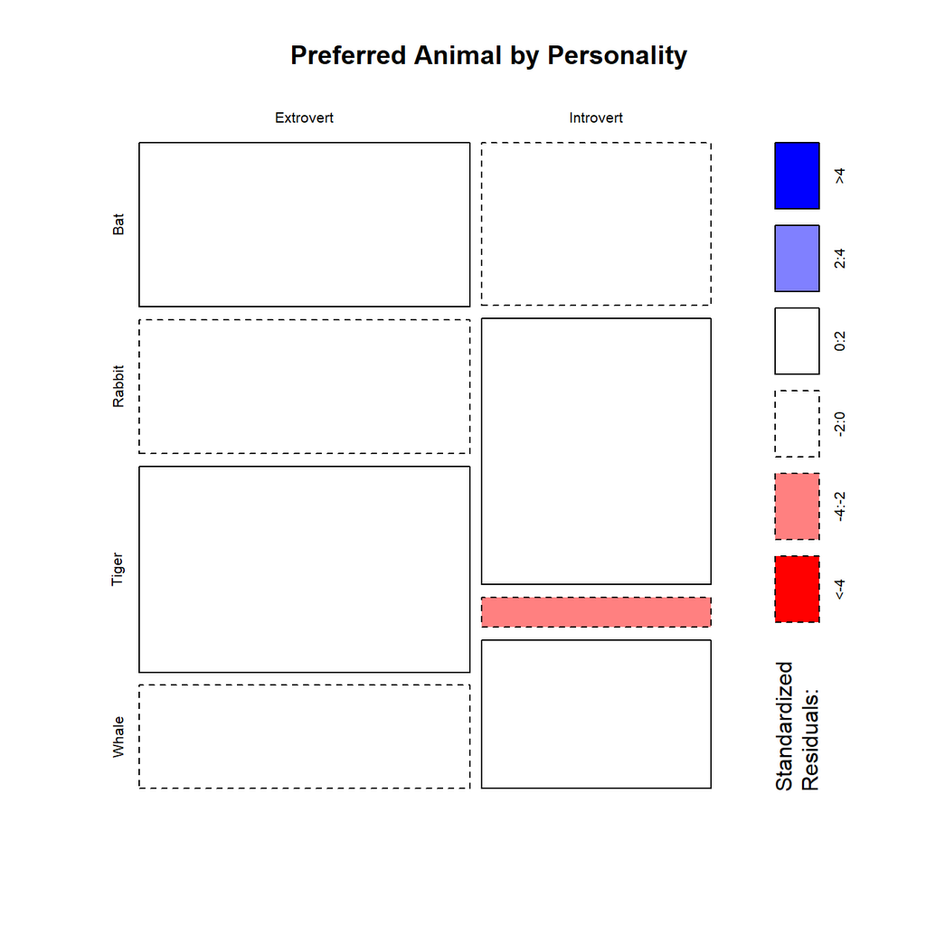

Figure 1: Preferred Animal by Personality

```r
library("graphics")

personalityConting %>%
    as.matrix() %>%
    as.table() %>%
    mosaicplot(main = 'Preferred Animal by Personality', shade = TRUE)
```

Chi-square test

```r
personRes <- chisq.test(personalityConting)

personTbl <-
    data.frame(
        `chi` = personRes$statistic,
        df = personRes$parameter,
        `p` = personRes$p.value,
        Method = personRes$method
        ) %>%
    rename(`Chi-squared` = chi)

library('gt')
personTbl %>%
    gt() %>%
tab_header(
    title = 'Table 1'
    , subtitle = 'Preferred Animal by Personality Type Chi-Square Results'
    ) %>%
  fmt_number(columns = c(`Chi-squared`)) %>%
  fmt_scientific(columns = c(p))
```

Table 1

Preferred Animal by Personality Type Chi-Square Results

| Chi-squared | df | p | Method |
| --- | --- | --- | --- |
| 13.66 | 3 | 3.40 × 10<sup>−3</sup> | Pearson's Chi-squared test |

There was a significant difference in animal preference by personality type. The data visualization in Figure 1 indicates that extroverts are more likely to prefer tigers than are introverts.

### Part 2: Was there an association between religiosity and a belief that abortion should be banned in Canada in 2011?

The `car` package provides the `CES11` data (Reference 2 and Reference 3).

```r
library('car')
```

I used these data to see if there was a relationship between religiosity and a belief that abortion should be banned in Canada in 2011.

```r
abConting <-
    CES11 %>%
    select(abortion, importance) %>%
    group_by(abortion, importance) %>%
    summarize(n = n()) %>%
    ungroup() %>%
    rename(`Abortion should be banned` = abortion) %>%
    pivot_wider(names_from = `Abortion should be banned`, values_from = n)

rnames <- abConting$importance

abConting %<>%
    select(-importance) %>%
    as.data.frame()

rownames(abConting) <- rnames

rm(rnames)

abConting
```

```
##           No Yes
## not      582  25
## notvery  295  20
## somewhat 620  94
## very     321 274
```

Data visualization (inspired by [Reference 1](http://www.sthda.com/english/wiki/chi-square-test-of-independence-in-r))

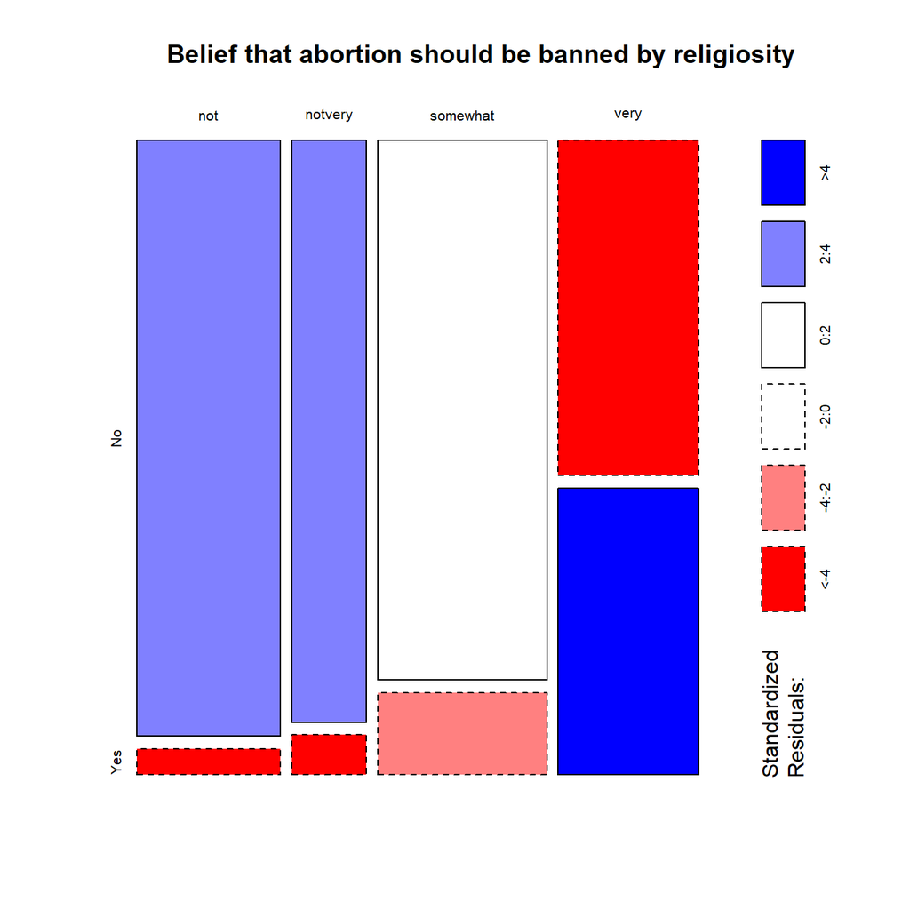

Figure 2: Religiosity (not religious to very religious) and a Belief that Abortion Should be Banned

```r
library("graphics")

abConting %>%
    as.matrix() %>%
    as.table() %>%
    mosaicplot(main = 'Belief that abortion should be banned by religiosity', shade = TRUE)
```

Chi-square test

```r
abRes <- chisq.test(abConting)

abTbl <-
    data.frame(
        `chi` = abRes$statistic,
        df = abRes$parameter,
        `p` = abRes$p.value,
        Method = abRes$method
        ) %>%
    rename(`Chi-squared` = chi)

abTbl %>%
    gt() %>%
tab_header(
    title = 'Table 2'
    , subtitle = 'Belief that Abortion Should be Banned by Religiosity Chi-Square Results'
    ) %>%
  fmt_number(columns = c(`Chi-squared`)) %>%
  fmt_scientific(columns = c(p))
```

Table 2

Belief that Abortion Should be Banned by Religiosity Chi-Square Results

| Chi-squared | df | p | Method |
| --- | --- | --- | --- |
| 426.91 | 3 | 3.28 × 10<sup>−92</sup> | Pearson's Chi-squared test |

There was a significant difference in the belief that abortion should be banned based on religiosity. The data visualization in Figure 2 indicates that if one is more religious, one is also more likely to believe that abortion should be banned.

## Discussion

### Part 1

Assertiveness or aggressiveness may be a personality trait that explains the association between extroversion and a preference for tigers, large predators. The same underlying personality trait may explain the association between introversion and a preference for rabbits, small prey animals.

### Part 2

The association between religiosity and a belief that abortion should be banned is not especially surprising. It would be interesting, however, to gather data that explores if beliefs about abortion change as a result of becoming religious or “losing” one’s religion (i.e., becoming agnostic or atheist after having been previously religious.)

## References

1. [STHDA: Statistical tools for high-throughput data analysis. Chi-Square Test of Independence in R](http://www.sthda.com/english/wiki/chi-square-test-of-independence-in-r)
2. Fournier, P., Cutler, F., Soroka, S., and Stolle, D. (2013). Canadian Election Study 2011: Study documentation. Technical report, Canadian Opinion Research Archive, Queen’s University, Kingson,Ontario.
3. Northrup, D. (2012). The 2011 Canadian Election Survey: Technical documention. Technical report, Institute for Social Research, York University, Toronto, Ontario.